# Group 26: Arcene Cancer

Worth noting is that classification trees are subject to overfitting and high-variance. We turn to other tree based methods, contained within randomForest, to see whether the accuracy of our method can be improved.

We begin by applying bagging to a tree for data with 13 PCs.

```r
# Use randomForset, with mtry set to the number of variables
set.seed(101)
bag_PCA13 <- randomForest(Class~., data=PCA13_train, mtry=13,
                          ntree=300) # 300 optimal
bag_PCA13
```

```
Call:
 randomForest(formula = Class ~ ., data = PCA13_train, mtry = 13,      ntree = 300)
               Type of random forest: classification
                     Number of trees: 300
No. of variables tried at each split: 13

        OOB estimate of  error rate: 20%
Confusion matrix:
   -1  1 class.error
-1 47  9   0.1607143
1  11 33   0.2500000
```

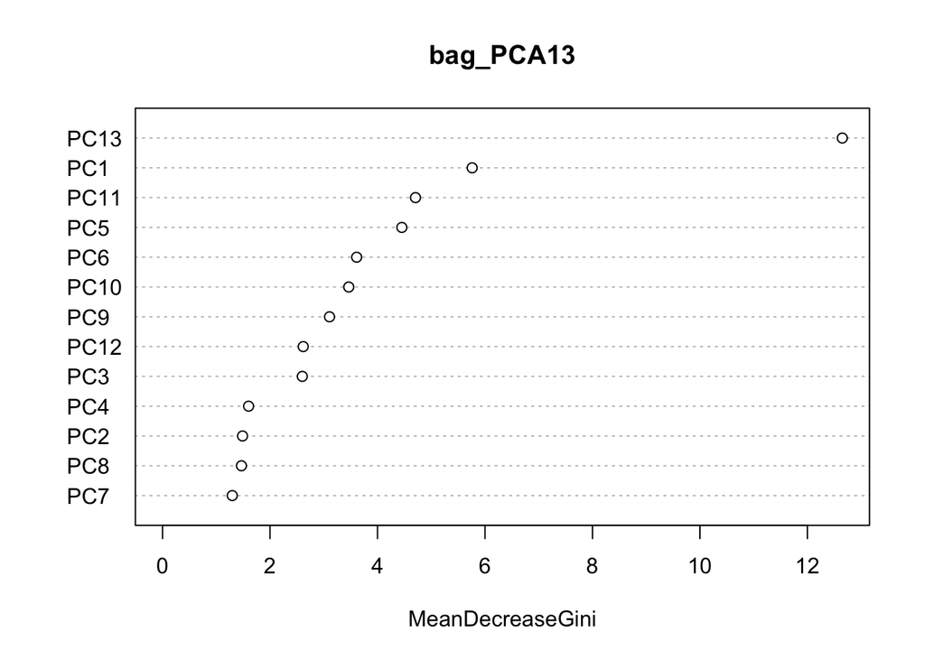

```r
varImpPlot(bag_PCA13)
```

```r
bag_PCA13_pred <- predict(bag_PCA13, newdata=PCA13_test, type="class")
class_rate_bag <- mean(bag_PCA13_pred==PCA13_test$Class)
class_rate_bag
```

```
[1] 0.8
```

Whilst PC13 remains significantly the most important variable, the relative importance of other variables is different in this method than the previous tree.

```r
set.seed(101)
bag_PCA40 <- randomForest(Class~., data=PCA40_train, mtry=40,
                          ntree=400) # 400 optimal
bag_PCA40
```

```
Call:
 randomForest(formula = Class ~ ., data = PCA40_train, mtry = 40,      ntree = 400)
               Type of random forest: classification
                     Number of trees: 400
No. of variables tried at each split: 40

        OOB estimate of  error rate: 23%
Confusion matrix:
   -1  1 class.error
-1 47  9   0.1607143
1  14 30   0.3181818
```

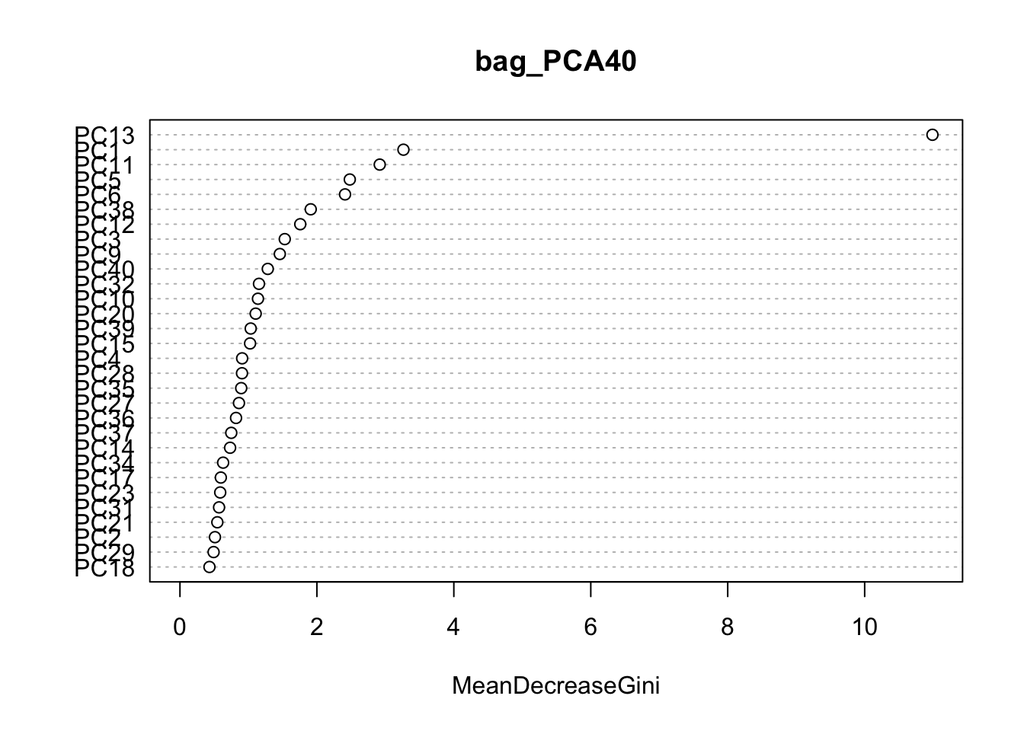

```r
varImpPlot(bag_PCA40)
```

```r
bag_PCA40_pred <- predict(bag_PCA40, newdata=PCA40_test, type="class")
class_rate_bag2 <- mean(bag_PCA40_pred==PCA40_test$Class)
class_rate_bag2
```

```
[1] 0.78
```

However, if we have observed anything so far it is that there is a dominant feature in this data, which leads to high correlation between bagged models, ultimately limiting the effect that bagging has on reducing variance.

We finally use a random forest method, which comabts the effects of dominant variables.

```r
# use randomForest without mtry argument
set.seed(101)
rf_PCA13 <- randomForest(Class~., data=PCA13_train, ntree=200)
rf_PCA13
```

```
Call:
 randomForest(formula = Class ~ ., data = PCA13_train, ntree = 200)
               Type of random forest: classification
                     Number of trees: 200
No. of variables tried at each split: 3

        OOB estimate of  error rate: 21%
Confusion matrix:
   -1  1 class.error
-1 49  7   0.1250000
1  14 30   0.3181818
```

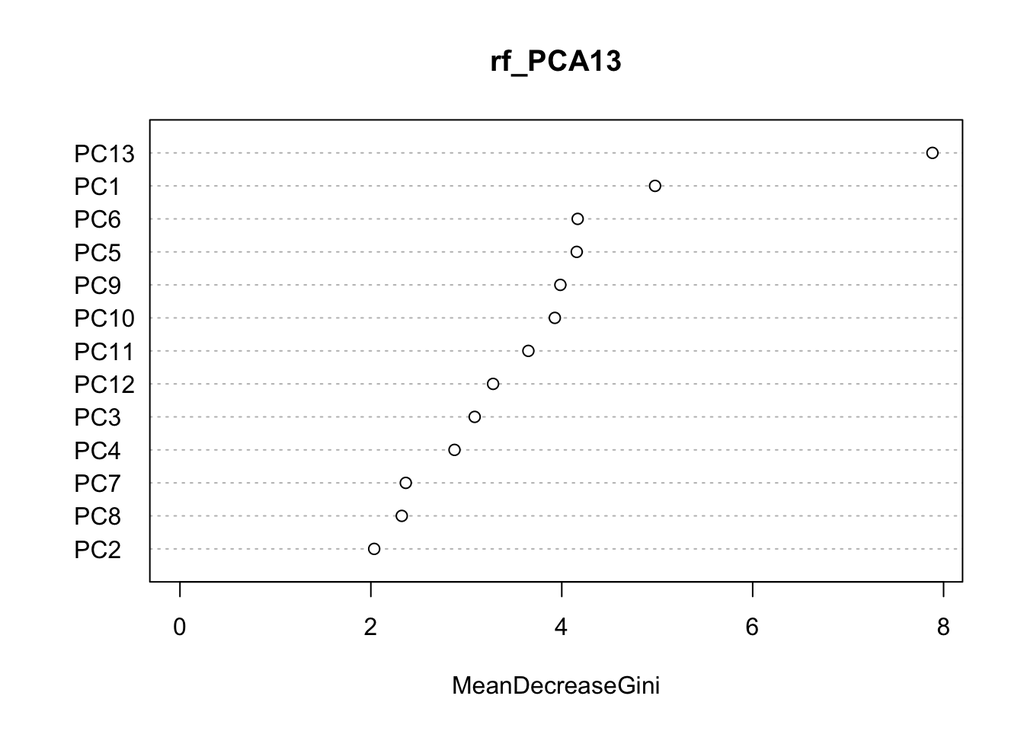

```r
varImpPlot(rf_PCA13)
```

```r
rf_PCA13_pred <- predict(rf_PCA13, newdata=PCA13_test, type="class")
class_rate_rf <- mean(rf_PCA13_pred==PCA13_test$Class)
class_rate_rf
```

```
[1] 0.79
```

```r
# use randomForest without mtry argument
set.seed(101)
rf_PCA40 <- randomForest(Class~., data=PCA40_train, ntree=200)
rf_PCA40
```

```
Call:
 randomForest(formula = Class ~ ., data = PCA40_train, ntree = 200)
               Type of random forest: classification
                     Number of trees: 200
No. of variables tried at each split: 6

        OOB estimate of  error rate: 24%
Confusion matrix:
   -1  1 class.error
-1 49  7   0.1250000
1  17 27   0.3863636
```

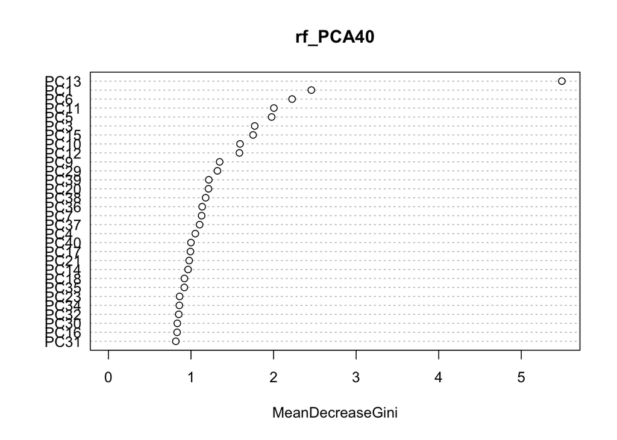

```r
varImpPlot(rf_PCA40)
```

```r
rf_PCA40_pred <- predict(rf_PCA40, newdata=PCA40_test, type="class")
class_rate_rf <- mean(rf_PCA40_pred==PCA40_test$Class)
class_rate_rf
```

```
[1] 0.78
```

No, of course it doesn’t make a change.